# Unsupervised Learning

Emily Blue

`2-26-24`

### Overview:

This R Markdown file includes my completion of **ISLR chapter 12**, exercises 8, 9, 12, and 13.

#### Exercises 8: Calculate PVE

- **Objective**: Calculate PVE using the prcomp() function.

#### Exercises 9: Hierarchical Clustering

- **Objective**: Perform hierarchical clustering on the states.
- **Steps**:
  - Cluster states using hierarchical clustering with complete linkage and Euclidean distance.
  - Perform hierarchically cluster again with scaled variables.

#### Exercises 12: Matrix Completion Function

- **Objective**: Write function to implement Iterative Algorithm for Matrix Completion.
- **Steps**:
  - Turn data frame into a matrix after scaling and centering columns.
  - Compute principal component, compute the objective, and return estimated missing entries.

#### Exercises 13: Healthy vs Diseased Genes

- **Objective**: Analyzing a gene expression dataset to differentiate between healthy and diseased groups.
- **Steps**:
  - Apply hierarchical clustering to samples using distance and plot the dendrogram.
  - Perform Principal Component Analysis and K-Means Clustering to differentiate between groups.

```r
library(tidyverse)
library(openintro)
library(dplyr)
library(ISLR2)
data("USArrests")
data("College")
library(pls)
```

## Calculate PVE

On the USArrests data, calculate PVE.

```r
states <- row.names(USArrests)
names(USArrests)
```

```
## [1] "Murder"   "Assault"  "UrbanPop" "Rape"
```

```r
pr.out <- prcomp(USArrests, scale = TRUE)
names(pr.out)
```

```
## [1] "sdev"     "rotation" "center"   "scale"    "x"
```

```r
pr.out$center
```

```
##   Murder  Assault UrbanPop     Rape
##    7.788  170.760   65.540   21.232
```

```r
pr.out$scale
```

```
##    Murder   Assault  UrbanPop      Rape
##  4.355510 83.337661 14.474763  9.366385
```

```r
pr.out$rotation
```

```
##                 PC1        PC2        PC3         PC4
## Murder   -0.5358995  0.4181809 -0.3412327  0.64922780
## Assault  -0.5831836  0.1879856 -0.2681484 -0.74340748
## UrbanPop -0.2781909 -0.8728062 -0.3780158  0.13387773
## Rape     -0.5434321 -0.1673186  0.8177779  0.08902432
```

```r
dim(pr.out$x)
```

```
## [1] 50  4
```

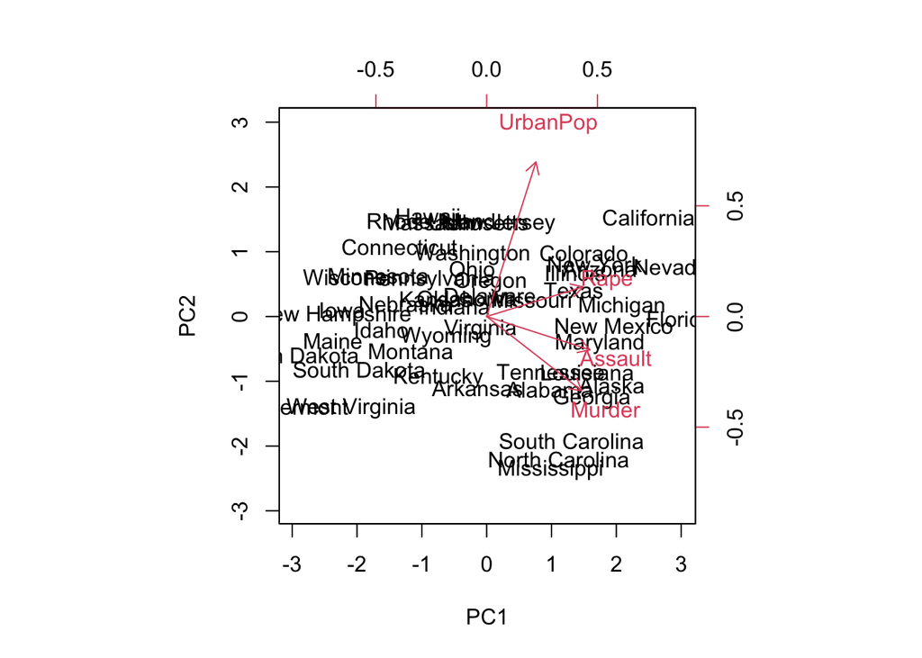

```r
pr.out$rotation = -pr.out$rotation
pr.out$x = -pr.out$x
biplot(pr.out, scale = 0)
```

```r
pr.var <- pr.out$sdev^2
pr.var
```

```
## [1] 2.4802416 0.9897652 0.3565632 0.1734301
```

```r
pve <- pr.var / sum(pr.var)
pve
```

```
## [1] 0.62006039 0.24744129 0.08914080 0.04335752
```

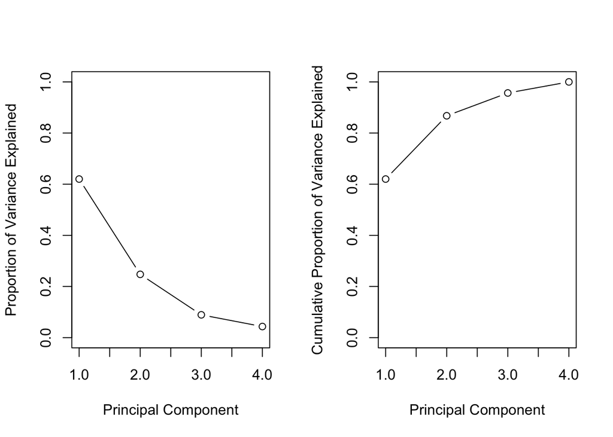

```r
# First principal component explains 62.0% of variance in the data, the next principal component explains 24.7% of variance, the next explains 8.91% of variance in data, the next explains 4.33% of variance in data


par(mfrow = c(1, 2))
plot(pve, xlab = "Principal Component",
ylab = "Proportion of Variance Explained", ylim = c(0, 1),
type = "b")
plot(cumsum(pve), xlab = "Principal Component",
ylab = "Cumulative Proportion of Variance Explained",
ylim = c(0, 1), type = "b")
```

```r
a <- c(1, 2, 8, -3)
cumsum(a)
```

```
## [1]  1  3 11  8
```

## Hierarchical Clustering

Use the USArrests data to perform hierarchical clustering on the states.

### a) Using hierarchical clustering with complete linkage and Euclidean distance, cluster the states.

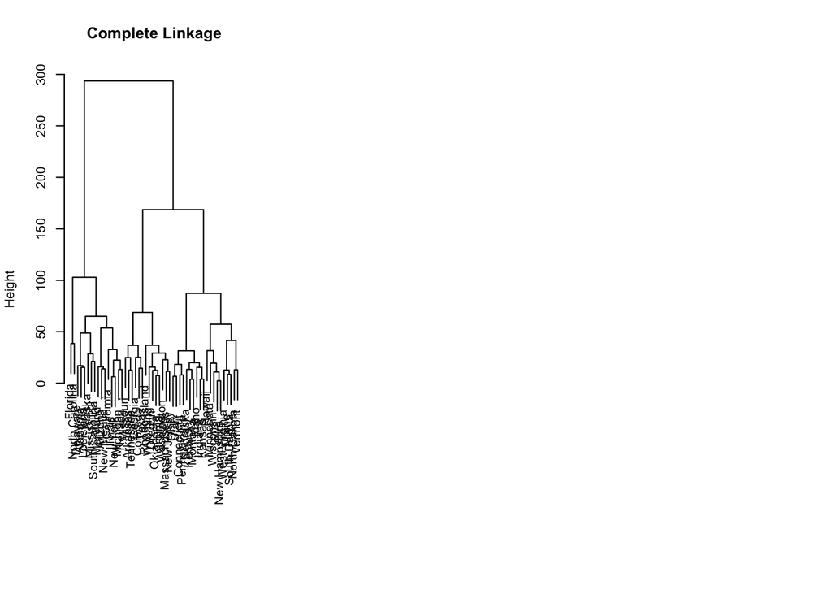

```r
set.seed(50)

x <- matrix(rnorm(50 * 2), ncol = 2)

hc.complete <- hclust(dist(USArrests), method = "complete")

par(mfrow = c(1, 3))
plot(hc.complete, main = "Complete Linkage",
xlab = "", sub = "", cex = .9)
```

### b) Cut the dendrogram at a height that results in three distinct clusters. Which states belong to which clusters?

```r
cutree(hc.complete, 3)
```

```
##        Alabama         Alaska        Arizona       Arkansas     California
##              1              1              1              2              1
##       Colorado    Connecticut       Delaware        Florida        Georgia
##              2              3              1              1              2
##         Hawaii          Idaho       Illinois        Indiana           Iowa
##              3              3              1              3              3
##         Kansas       Kentucky      Louisiana          Maine       Maryland
##              3              3              1              3              1
##  Massachusetts       Michigan      Minnesota    Mississippi       Missouri
##              2              1              3              1              2
##        Montana       Nebraska         Nevada  New Hampshire     New Jersey
##              3              3              1              3              2
##     New Mexico       New York North Carolina   North Dakota           Ohio
##              1              1              1              3              3
##       Oklahoma         Oregon   Pennsylvania   Rhode Island South Carolina
##              2              2              3              2              1
##   South Dakota      Tennessee          Texas           Utah        Vermont
##              3              2              2              3              3
##       Virginia     Washington  West Virginia      Wisconsin        Wyoming
##              2              2              3              3              2
```

### c) Hierarchically cluster the states using complete linkage and Euclidean distance after scaling the variables.

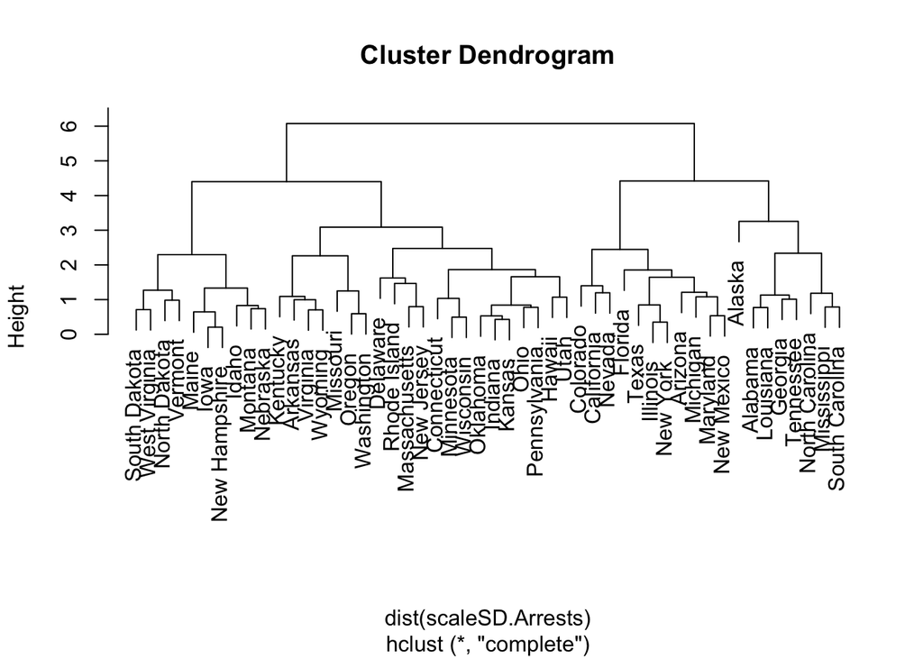

```r
scaleSD.Arrests = scale(USArrests)

hc.complete.scaleSD <- hclust(dist(scaleSD.Arrests), method = "complete")

plot(hc.complete.scaleSD, method = "complete")
```

### d) What efect does scaling the variables have on the hierarchical clustering obtained?

```r
cutree(hc.complete.scaleSD,3)
```

```
##        Alabama         Alaska        Arizona       Arkansas     California
##              1              1              2              3              2
##       Colorado    Connecticut       Delaware        Florida        Georgia
##              2              3              3              2              1
##         Hawaii          Idaho       Illinois        Indiana           Iowa
##              3              3              2              3              3
##         Kansas       Kentucky      Louisiana          Maine       Maryland
##              3              3              1              3              2
##  Massachusetts       Michigan      Minnesota    Mississippi       Missouri
##              3              2              3              1              3
##        Montana       Nebraska         Nevada  New Hampshire     New Jersey
##              3              3              2              3              3
##     New Mexico       New York North Carolina   North Dakota           Ohio
##              2              2              1              3              3
##       Oklahoma         Oregon   Pennsylvania   Rhode Island South Carolina
##              3              3              3              3              1
##   South Dakota      Tennessee          Texas           Utah        Vermont
##              3              1              2              3              3
##       Virginia     Washington  West Virginia      Wisconsin        Wyoming
##              3              3              3              3              3
```

```r
table(cutree(hc.complete,3),cutree(hc.complete.scaleSD,3))
```

```
##
##      1  2  3
##   1  6  9  1
##   2  2  2 10
##   3  0  0 20
```

## Matrix Completion Function

### Write a function to implement Algorithm 12.1 using prcomp().

```r
# Centering and scaling each column to have mean 0 and variance 1.
X <- data.matrix(scale(USArrests))
pcob <- prcomp(X)
summary(pcob)
```

```
## Importance of components:
##                           PC1    PC2     PC3     PC4
## Standard deviation     1.5749 0.9949 0.59713 0.41645
## Proportion of Variance 0.6201 0.2474 0.08914 0.04336
## Cumulative Proportion  0.6201 0.8675 0.95664 1.00000
```

```r
# singular value decomposition
sX <- svd(X)
names(sX)
```

```
## [1] "d" "u" "v"
```

```r
round(sX$v, 3)
```

```
##        [,1]   [,2]   [,3]   [,4]
## [1,] -0.536  0.418 -0.341  0.649
## [2,] -0.583  0.188 -0.268 -0.743
## [3,] -0.278 -0.873 -0.378  0.134
## [4,] -0.543 -0.167  0.818  0.089
```

```r
pcob$rotation
```

```
##                 PC1        PC2        PC3         PC4
## Murder   -0.5358995  0.4181809 -0.3412327  0.64922780
## Assault  -0.5831836  0.1879856 -0.2681484 -0.74340748
## UrbanPop -0.2781909 -0.8728062 -0.3780158  0.13387773
## Rape     -0.5434321 -0.1673186  0.8177779  0.08902432
```

```r
t(sX$d * t(sX$u))
```

```
##              [,1]        [,2]        [,3]         [,4]
##  [1,] -0.97566045  1.12200121 -0.43980366  0.154696581
##  [2,] -1.93053788  1.06242692  2.01950027 -0.434175454
##  [3,] -1.74544285 -0.73845954  0.05423025 -0.826264240
##  [4,]  0.13999894  1.10854226  0.11342217 -0.180973554
##  [5,] -2.49861285 -1.52742672  0.59254100 -0.338559240
##  [6,] -1.49934074 -0.97762966  1.08400162  0.001450164
##  [7,]  1.34499236 -1.07798362 -0.63679250 -0.117278736
##  [8,] -0.04722981 -0.32208890 -0.71141032 -0.873113315
##  [9,] -2.98275967  0.03883425 -0.57103206 -0.095317042
## [10,] -1.62280742  1.26608838 -0.33901818  1.065974459
## [11,]  0.90348448 -1.55467609  0.05027151  0.893733198
## [12,]  1.62331903  0.20885253  0.25719021 -0.494087852
## [13,] -1.36505197 -0.67498834 -0.67068647 -0.120794916
## [14,]  0.50038122 -0.15003926  0.22576277  0.420397595
```

[output cut: 36 more lines]

```r
pcob$x
```

```
##                        PC1         PC2         PC3          PC4
## Alabama        -0.97566045  1.12200121 -0.43980366  0.154696581
## Alaska         -1.93053788  1.06242692  2.01950027 -0.434175454
## Arizona        -1.74544285 -0.73845954  0.05423025 -0.826264240
## Arkansas        0.13999894  1.10854226  0.11342217 -0.180973554
## California     -2.49861285 -1.52742672  0.59254100 -0.338559240
## Colorado       -1.49934074 -0.97762966  1.08400162  0.001450164
## Connecticut     1.34499236 -1.07798362 -0.63679250 -0.117278736
## Delaware       -0.04722981 -0.32208890 -0.71141032 -0.873113315
## Florida        -2.98275967  0.03883425 -0.57103206 -0.095317042
## Georgia        -1.62280742  1.26608838 -0.33901818  1.065974459
## Hawaii          0.90348448 -1.55467609  0.05027151  0.893733198
## Idaho           1.62331903  0.20885253  0.25719021 -0.494087852
## Illinois       -1.36505197 -0.67498834 -0.67068647 -0.120794916
## Indiana         0.50038122 -0.15003926  0.22576277  0.420397595
## Iowa            2.23099579 -0.10300828  0.16291036  0.017379470
## Kansas          0.78887206 -0.26744941  0.02529648  0.204421034
## Kentucky        0.74331256  0.94880748 -0.02808429  0.663817237
## Louisiana      -1.54909076  0.86230011 -0.77560598  0.450157791
## Maine           2.37274014  0.37260865 -0.06502225 -0.327138529
## Maryland       -1.74564663  0.42335704 -0.15566968 -0.553450589
## Massachusetts   0.48128007 -1.45967706 -0.60337172 -0.177793902
## Michigan       -2.08725025 -0.15383500  0.38100046  0.101343128
## Minnesota       1.67566951 -0.62590670  0.15153200  0.066640316
## Mississippi    -0.98647919  2.36973712 -0.73336290  0.213342049
## Missouri       -0.68978426 -0.26070794  0.37365033  0.223554811
## Montana         1.17353751  0.53147851  0.24440796  0.122498555
## Nebraska        1.25291625 -0.19200440  0.17380930  0.015733156
## Nevada         -2.84550542 -0.76780502  1.15168793  0.311354436
## New Hampshire   2.35995585 -0.01790055  0.03648498 -0.032804291
## New Jersey     -0.17974128 -1.43493745 -0.75677041  0.240936580
## New Mexico     -1.96012351  0.14141308  0.18184598 -0.336121113
## New York       -1.66566662 -0.81491072 -0.63661186 -0.013348844
## North Carolina -1.11208808  2.20561081 -0.85489245 -0.944789648
## North Dakota    2.96215223  0.59309738  0.29824930 -0.251434626
## Ohio            0.22369436 -0.73477837 -0.03082616  0.469152817
## Oklahoma        0.30864928 -0.28496113 -0.01515592  0.010228476
## Oregon         -0.05852787 -0.53596999  0.93038718 -0.235390872
## Pennsylvania    0.87948680 -0.56536050 -0.39660218  0.355452378
## Rhode Island    0.85509072 -1.47698328 -1.35617705 -0.607402746
## South Carolina -1.30744986  1.91397297 -0.29751723 -0.130145378
## South Dakota    1.96779669  0.81506822  0.38538073 -0.108470512
## Tennessee      -0.98969377  0.85160534  0.18619262  0.646302674
## Texas          -1.34151838 -0.40833518 -0.48712332  0.636731051
## Utah            0.54503180 -1.45671524  0.29077592 -0.081486749
## Vermont         2.77325613  1.38819435  0.83280797 -0.143433697
## Virginia        0.09536670  0.19772785  0.01159482  0.209246429
## Washington      0.21472339 -0.96037394  0.61859067 -0.218628161
## West Virginia   2.08739306  1.41052627  0.10372163  0.130583080
## Wisconsin       2.05881199 -0.60512507 -0.13746933  0.182253407
## Wyoming         0.62310061  0.31778662 -0.23824049 -0.164976866
```

```r
## Replace svd() with prcomp()
nomit <- 20

set.seed(50)
ina <- sample(seq(50), nomit)
inb <- sample(1:4, nomit, replace = TRUE)
Xna <- X
index.na <- cbind(ina, inb)
Xna[index.na] <- NA


# Step 1
fit.prcomp <- function(X, M = 1) {
 prob <- prcomp(X)
 with(prob,
u[, 1:M, drop = FALSE] %*%
(d[1:M] * t(v[, 1:M, drop = FALSE]))
)
}


fit.prcomp <- function(X, M = 1) {
 prob <- prcomp(X)
 with(prob,
sX$u[, 1:M, drop = FALSE] %*%
(sX$d[1:M] * t(sX$v[, 1:M, drop = FALSE]))
)
}

Xhat <- Xna
xbar <- colMeans(Xna, na.rm = TRUE)
Xhat[index.na] <- xbar[inb]

thresh <- 1e-7
rel_err <- 1
iter <- 0
ismiss <- is.na(Xna)
mssold <- mean((scale(Xna, xbar, FALSE)[!ismiss])^2)
mss0 <- mean(Xna[!ismiss]^2)

#Step 1
 while(rel_err > thresh) {
iter <- iter + 1
 # Step 2(a)
 Xapp <- fit.prcomp(Xhat, M = 1)
 # Step 2(b)
 Xhat[ismiss] <- Xapp[ismiss]
 # Step 2(c)
 mss <- mean(((Xna - Xapp)[!ismiss])^2)
 rel_err <- (mssold - mss) / mss0
 mssold <- mss
 cat("Iter:", iter, "MSS:", mss,
 "Rel. Err:", rel_err, "\n")
 }
```

```
## Iter: 1 MSS: 0.3666684 Rel. Err: 0.6219208
## Iter: 2 MSS: 0.3666684 Rel. Err: 0
```

```r
# Correlation between the 20 imputed values and the actual values
cor(Xapp[ismiss], X[ismiss])
```

```
## [1] 0.7586529
```

## Healthy vs Diseased Genes

There is a gene expression data set (Ch12Ex13.csv) that consists of 40 tissue samples with measurements on 1,000 genes. The first 20 samples are from healthy patients, while the second 20 are from a diseased group.

### b) Apply hierarchical clustering to the samples using correlation based distance, and plot the dendrogram. Do the genes separate the samples into the two groups? Do your results depend on the type of linkage used?

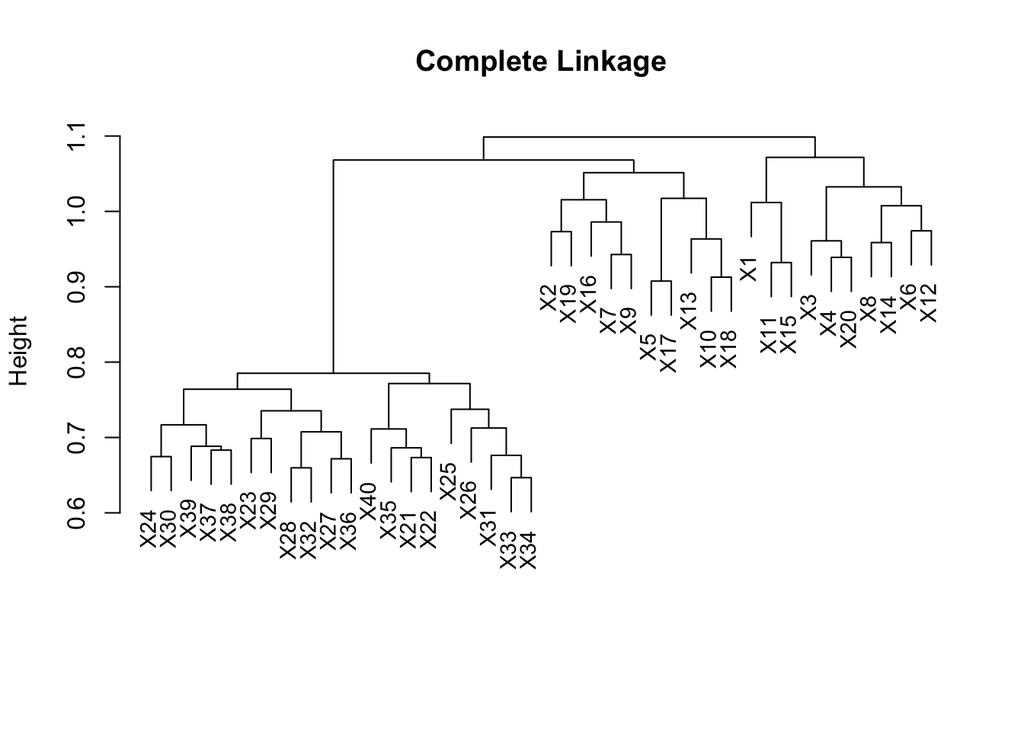

```r
set.seed(50)

# complete
hc.complete <- hclust(as.dist(1 - cor(Samples)), method='complete')

plot(hc.complete, main = "Complete Linkage",
xlab = "", sub = "", cex = .9)
```

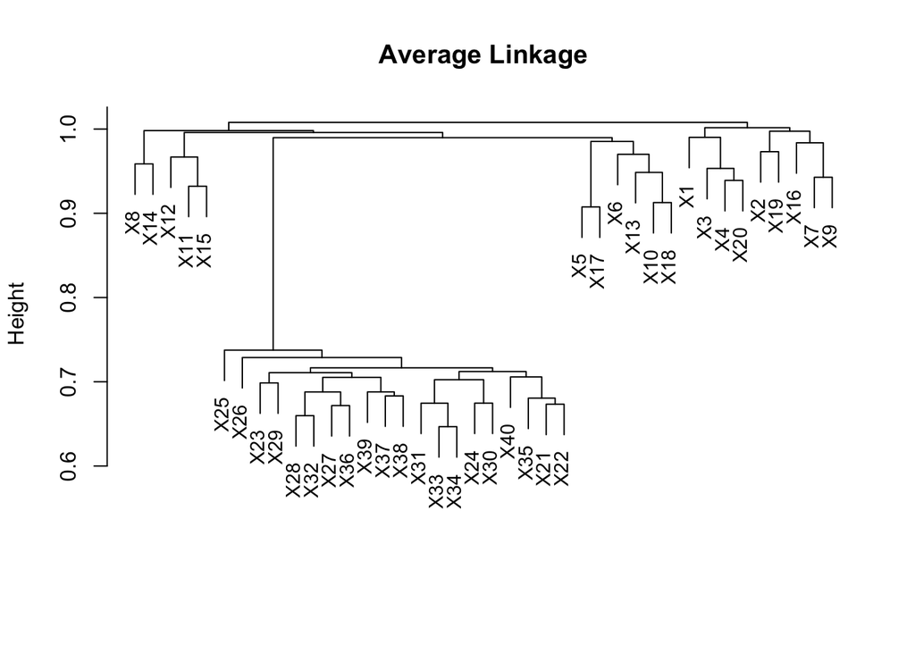

```r
# average
hc.average <- hclust(as.dist(1 - cor(Samples)), method = "average")

plot(hc.average, main = "Average Linkage",
xlab = "", sub = "", cex = .9)
```

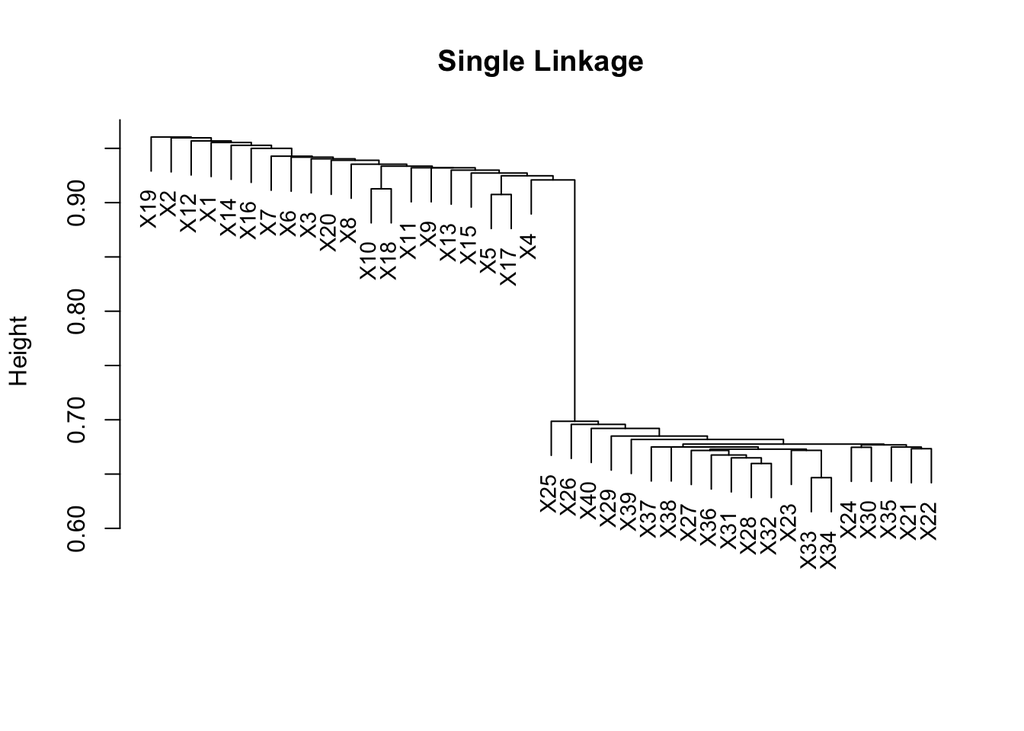

```r
#single
hc.single <- hclust(as.dist(1 - cor(Samples)), method = "single")

plot(hc.single, main = "Single Linkage",
xlab = "", sub = "", cex = .9)
```

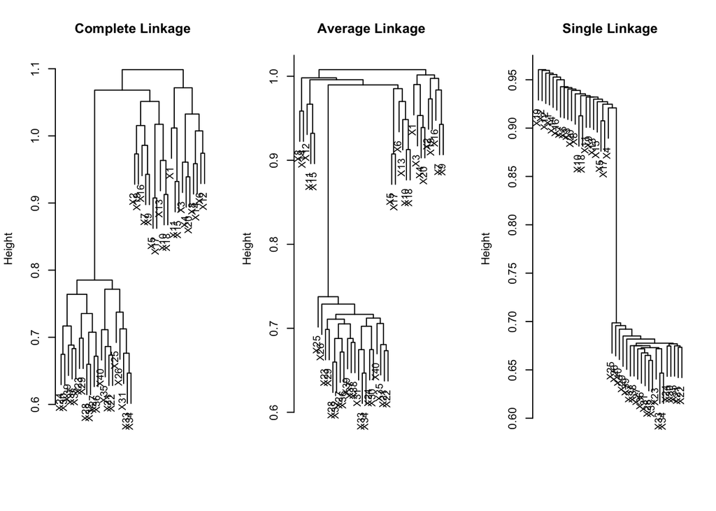

```r
par(mfrow = c(1, 3))
plot(hc.complete, main = "Complete Linkage",
xlab = "", sub = "", cex = .9)
plot(hc.average, main = "Average Linkage",
xlab = "", sub = "", cex = .9)
plot(hc.single, main = "Single Linkage",
xlab = "", sub = "", cex = .9)
```

The choice of method affects the results and clusters obtained. It shows two clusters formed for single and complete linkage while average linkage has three clusters.

### c) Your collaborator wants to know which genes difer the most across the two groups. Suggest a way to answer this question, and apply it here.

I would suggest performing Principal Component Analysis (PCA) or K-Means Clustering to differentiate between the healthy and diseased groups

### Principal Component Analysis (PCA)

```r
Samples.labs <- Samples$labs
Samples.data <- Samples$data
pr.Samples <- prcomp(Samples, scale = TRUE)
summary(pr.Samples)
```

```
## Importance of components:
##                           PC1    PC2     PC3     PC4     PC5     PC6     PC7
## Standard deviation     2.5401 1.1455 1.12727 1.10915 1.09034 1.06729 1.06464
## Proportion of Variance 0.1613 0.0328 0.03177 0.03076 0.02972 0.02848 0.02834
## Cumulative Proportion  0.1613 0.1941 0.22587 0.25663 0.28635 0.31483 0.34316
##                            PC8     PC9    PC10   PC11   PC12   PC13    PC14
## Standard deviation     1.05514 1.04623 1.03430 1.0218 1.0040 1.0000 0.99680
## Proportion of Variance 0.02783 0.02736 0.02674 0.0261 0.0252 0.0250 0.02484
## Cumulative Proportion  0.37100 0.39836 0.42510 0.4512 0.4764 0.5014 0.52625
##                           PC15   PC16    PC17    PC18    PC19    PC20    PC21
## Standard deviation     0.97913 0.9674 0.96207 0.95900 0.94880 0.93664 0.91466
## Proportion of Variance 0.02397 0.0234 0.02314 0.02299 0.02251 0.02193 0.02092
## Cumulative Proportion  0.55021 0.5736 0.59675 0.61974 0.64225 0.66418 0.68509
##                           PC22    PC23    PC24    PC25    PC26   PC27    PC28
## Standard deviation     0.90370 0.89974 0.87668 0.86341 0.85710 0.8532 0.84544
## Proportion of Variance 0.02042 0.02024 0.01921 0.01864 0.01837 0.0182 0.01787
## Cumulative Proportion  0.70551 0.72575 0.74496 0.76360 0.78196 0.8002 0.81803
##                           PC29    PC30    PC31    PC32   PC33    PC34    PC35
## Standard deviation     0.83839 0.82676 0.81452 0.79681 0.7924 0.78095 0.77890
## Proportion of Variance 0.01757 0.01709 0.01659 0.01587 0.0157 0.01525 0.01517
## Cumulative Proportion  0.83561 0.85269 0.86928 0.88515 0.9009 0.91610 0.93126
##                           PC36   PC37    PC38    PC39    PC40
## Standard deviation     0.77086 0.7509 0.74522 0.72987 0.70944
## Proportion of Variance 0.01486 0.0141 0.01388 0.01332 0.01258
## Cumulative Proportion  0.94612 0.9602 0.97410 0.98742 1.00000
```

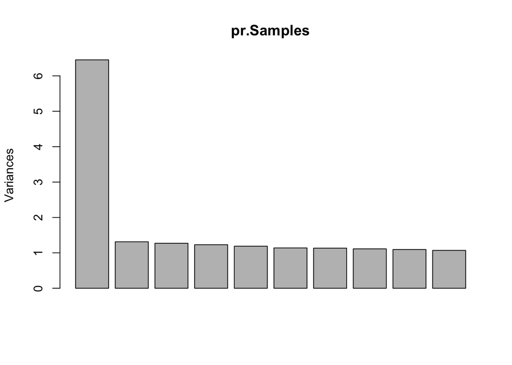

```r
plot(pr.Samples)
```

```r
dim(pr.Samples$x)
```

```
## [1] 1000   40
```

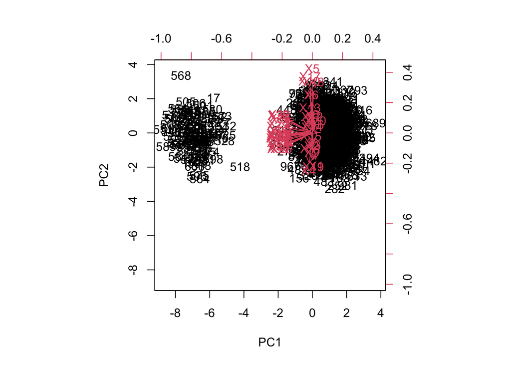

```r
biplot(pr.Samples, scale = 0)
```

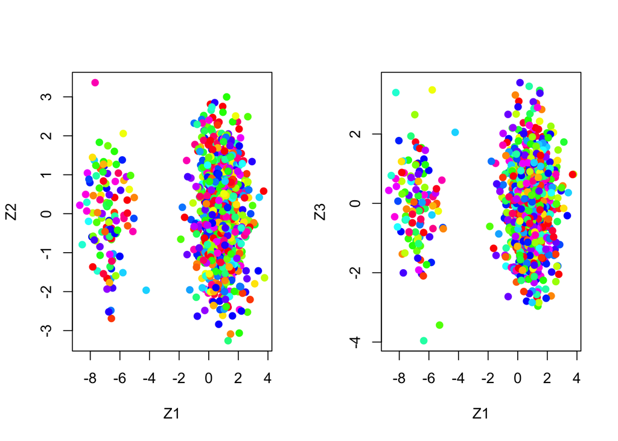

```r
Cols <- function(vec) {
cols <- rainbow(length(unique(vec)))
return(cols[as.numeric(as.factor(vec))])
}


par(mfrow = c(1, 2))
plot(pr.Samples$x[, 1:2], col = Cols(Samples), pch = 19,
xlab = "Z1", ylab = "Z2")
plot(pr.Samples$x[, c(1, 3)], col = Cols(Samples), pch = 19,
xlab = "Z1", ylab = "Z3")
```

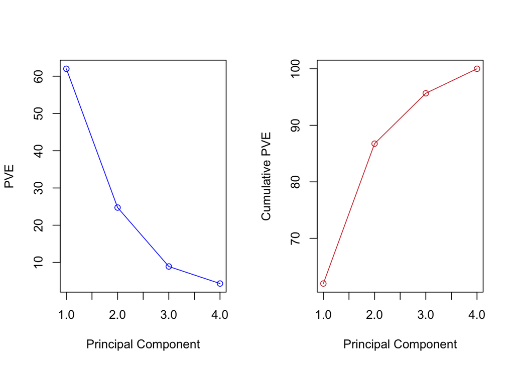

```r
# PVE of each principal component and the cumulative PVE of each principal component
pve <- 100 * pr.out$sdev^2 / sum(pr.out$sdev^2)
par(mfrow = c(1, 2))
plot(pve, type = "o", ylab = "PVE",
xlab = "Principal Component", col = "blue")
plot(cumsum(pve), type = "o", ylab = "Cumulative PVE",
xlab = "Principal Component", col = "brown3")
```

### K-Means Clustering

```r
set.seed(40)

km.Samples <- kmeans(Samples, 2, nstart = 20)
summary(km.Samples)
```

```
##              Length Class  Mode
## cluster      1000   -none- numeric
## centers        80   -none- numeric
## totss           1   -none- numeric
## withinss        2   -none- numeric
## tot.withinss    1   -none- numeric
## betweenss       1   -none- numeric
## size            2   -none- numeric
## iter            1   -none- numeric
## ifault          1   -none- numeric
```

```r
km.Samples$cluster
```

```
##    [1] 1 1 1 1 1 1 1 1 1 1 2 2 2 2 2 2 2 2 2 2 1 1 1 1 1 1 1 1 1 1 1 1 1 1 1 1 1
##   [38] 1 1 1 1 1 1 1 1 1 1 1 1 1 1 1 1 1 1 1 1 1 1 1 1 1 1 1 1 1 1 1 1 1 1 1 1 1
##   [75] 1 1 1 1 1 1 1 1 1 1 1 1 1 1 1 1 1 1 1 1 1 1 1 1 1 1 1 1 1 1 1 1 1 1 1 1 1
##  [112] 1 1 1 1 1 1 1 1 1 1 1 1 1 1 1 1 1 1 1 1 1 1 1 1 1 1 1 1 1 1 1 1 1 1 1 1 1
##  [149] 1 1 1 1 1 1 1 1 1 1 1 1 1 1 1 1 1 1 1 1 1 1 1 1 1 1 1 1 1 1 1 1 1 1 1 1 1
##  [186] 1 1 1 1 1 1 1 1 1 1 1 1 1 1 1 1 1 1 1 1 1 1 1 1 1 1 1 1 1 1 1 1 1 1 1 1 1
##  [223] 1 1 1 1 1 1 1 1 1 1 1 1 1 1 1 1 1 1 1 1 1 1 1 1 1 1 1 1 1 1 1 1 1 1 1 1 1
##  [260] 1 1 1 1 1 1 1 1 1 1 1 1 1 1 1 1 1 1 1 1 1 1 1 1 1 1 1 1 1 1 1 1 1 1 1 1 1
##  [297] 1 1 1 1 1 1 1 1 1 1 1 1 1 1 1 1 1 1 1 1 1 1 1 1 1 1 1 1 1 1 1 1 1 1 1 1 1
##  [334] 1 1 1 1 1 1 1 1 1 1 1 1 1 1 1 1 1 1 1 1 1 1 1 1 1 1 1 1 1 1 1 1 1 1 1 1 1
##  [371] 1 1 1 1 1 1 1 1 1 1 1 1 1 1 1 1 1 1 1 1 1 1 1 1 1 1 1 1 1 1 1 1 1 1 1 1 1
##  [408] 1 1 1 1 1 1 1 1 1 1 1 1 1 1 1 1 1 1 1 1 1 1 1 1 1 1 1 1 1 1 1 1 1 1 1 1 1
##  [445] 1 1 1 1 1 1 1 1 1 1 1 1 1 1 1 1 1 1 1 1 1 1 1 1 1 1 1 1 1 1 1 1 1 1 1 1 1
##  [482] 1 1 1 1 1 1 1 1 1 1 1 1 1 1 1 1 1 1 1 2 2 2 2 2 2 2 2 2 2 2 2 2 2 2 2 2 2
##  [519] 2 2 2 2 2 2 2 2 2 2 2 2 2 2 2 2 2 2 2 2 2 2 2 2 2 2 2 2 2 2 2 2 2 2 2 2 2
##  [556] 2 2 2 2 2 2 2 2 2 2 2 2 2 2 2 2 2 2 2 2 2 2 2 2 2 2 2 2 2 2 2 2 2 2 2 2 2
##  [593] 2 2 2 2 2 2 2 2 1 1 1 1 1 1 1 1 1 1 1 1 1 1 1 1 1 1 1 1 1 1 1 1 1 1 1 1 1
##  [630] 1 1 1 1 1 1 1 1 1 1 1 1 1 1 1 1 1 1 1 1 1 1 1 1 1 1 1 1 1 1 1 1 1 1 1 1 1
##  [667] 1 1 1 1 1 1 1 1 1 1 1 1 1 1 1 1 1 1 1 1 1 1 1 1 1 1 1 1 1 1 1 1 1 1 1 1 1
##  [704] 1 1 1 1 1 1 1 1 1 1 1 1 1 1 1 1 1 1 1 1 1 1 1 1 1 1 1 1 1 1 1 1 1 1 1 1 1
##  [741] 1 1 1 1 1 1 1 1 1 1 1 1 1 1 1 1 1 1 1 1 1 1 1 1 1 1 1 1 1 1 1 1 1 1 1 1 1
##  [778] 1 1 1 1 1 1 1 1 1 1 1 1 1 1 1 1 1 1 1 1 1 1 1 1 1 1 1 1 1 1 1 1 1 1 1 1 1
##  [815] 1 1 1 1 1 1 1 1 1 1 1 1 1 1 1 1 1 1 1 1 1 1 1 1 1 1 1 1 1 1 1 1 1 1 1 1 1
##  [852] 1 1 1 1 1 1 1 1 1 1 1 1 1 1 1 1 1 1 1 1 1 1 1 1 1 1 1 1 1 1 1 1 1 1 1 1 1
##  [889] 1 1 1 1 1 1 1 1 1 1 1 1 1 1 1 1 1 1 1 1 1 1 1 1 1 1 1 1 1 1 1 1 1 1 1 1 1
##  [926] 1 1 1 1 1 1 1 1 1 1 1 1 1 1 1 1 1 1 1 1 1 1 1 1 1 1 1 1 1 1 1 1 1 1 1 1 1
##  [963] 1 1 1 1 1 1 1 1 1 1 1 1 1 1 1 1 1 1 1 1 1 1 1 1 1 1 1 1 1 1 1 1 1 1 1 1 1
## [1000] 1
```

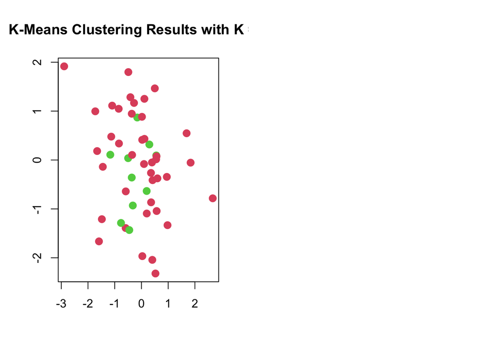

```r
par(mfrow = c(1, 2))
plot(x, col = (km.Samples$cluster + 1),
main = "K-Means Clustering Results with K = 2",
xlab = "", ylab = "", pch = 20, cex = 2)
```

…